#7TotaldescriptivaClean5.Rmd

#install.packages(“rmarkdown”)

#library(“rmarkdown”)

Información para la modificación

Para instalar el latex para r poner el comando en la consola: tinytex::install_tinytex()

Algunos de los parametros de cada chunk de codigo para poder deshabilitar algunos outputs. No me sé los valores por defecto :)

include = FALSE prevents code and results from appearing in the finished file. R Markdown still runs the code in the chunk, and the results can be used by other chunks. echo = FALSE prevents code, but not the results from appearing in the finished file. This is a useful way to embed figures. message = FALSE prevents messages that are generated by code from appearing in the finished file. warning = FALSE prevents warnings that are generated by code from appearing in the finished. fig.cap = “…” adds a caption to graphical results.

Ponemos la carpeta en la que estamos y cargamos el dataset elegido

```r
setwd("/home/pablesky/Documentos/MD-FIB")
dd<- read.csv("weathertrain.csv")
```

Imprimos alguna información importante sobre el dataset seleccionado como en este caso el número de filas, el número de columnas y el nombre de las columnas.

```r
class(dd)
```

```
## [1] "data.frame"
```

```r
dim(dd)
```

```
## [1] 99516    23
```

```r
filas<-dim(dd)[1]
columnas<-dim(dd)[2]

filas
```

```
## [1] 99516
```

```r
columnas
```

```
## [1] 23
```

```r
names(dd)
```

```
##  [1] "row.ID"        "Location"      "MinTemp"       "MaxTemp"
##  [5] "Rainfall"      "Evaporation"   "Sunshine"      "WindGustDir"
##  [9] "WindGustSpeed" "WindDir9am"    "WindDir3pm"    "WindSpeed9am"
## [13] "WindSpeed3pm"  "Humidity9am"   "Humidity3pm"   "Pressure9am"
## [17] "Pressure3pm"   "Cloud9am"      "Cloud3pm"      "Temp9am"
## [21] "Temp3pm"       "RainToday"     "RainTomorrow"
```

Función dedicada a imprimir los datos en forma de gráficas de cada columna por individual, hay que intentar quitar la primera columna en el caso que la primera columna sea solamente RowX o el índice de la tabla.

```r
descriptiva<-function(X, nom){
  if (!(is.numeric(X) || class(X)=="Date")){
    frecs<-table(as.factor(X), useNA="ifany")
    proportions<-frecs/filas
    #ojo, decidir si calcular porcentages con o sin missing values
    pie(frecs, cex=0.6, main=paste("Pie of", nom))
    barplot(frecs, las=3, cex.names=0.7, main=paste("Barplot of", nom), col=listOfColors)
    print(paste("Number of modalities: ", length(frecs)))
    print("Frequency table")
    print(frecs)
    print("Relative frequency table (proportions)")
    print(proportions)
    print("Frequency table sorted")
    print(sort(frecs, decreasing=TRUE))
    print("Relative frequency table (proportions) sorted")
    print(sort(proportions, decreasing=TRUE))
   }else{
     if(class(X)=="Date"){
       print(summary(X))
       print(sd(X))
       #decide breaks: weeks, months, quarters...
       hist(X,breaks="weeks")
     }else{
       hist(X, main=paste("Histogram of", nom))
       boxplot(X, horizontal=TRUE, main=paste("Boxplot of",nom))
       print("Extended Summary Statistics")
       print(summary(X))
       print(paste("sd: ", sd(X, na.rm=TRUE)))
       print(paste("vc: ", sd(X, na.rm=TRUE)/mean(X, na.rm=TRUE)))
      }
   }
}
```

Ejecución de la función por cada columna. La variable c es el rango desde la columna inicial hasta la columna final, es decir si ponemos 1:23 hará la ejecución desde la primera columna hasta la columna 23.

Ponemos el 2 en el inicio del recorrido para skipear la columna de row.

```r
listOfColors<-rainbow(39)

par(ask=TRUE)
actives<-c(2:columnas)
for(k in actives){
  print(paste("variable ", k, ":", names(dd)[k] ))
  descriptiva(dd[,k], names(dd)[k])
}
```

```
## [1] "variable  2 : Location"
```

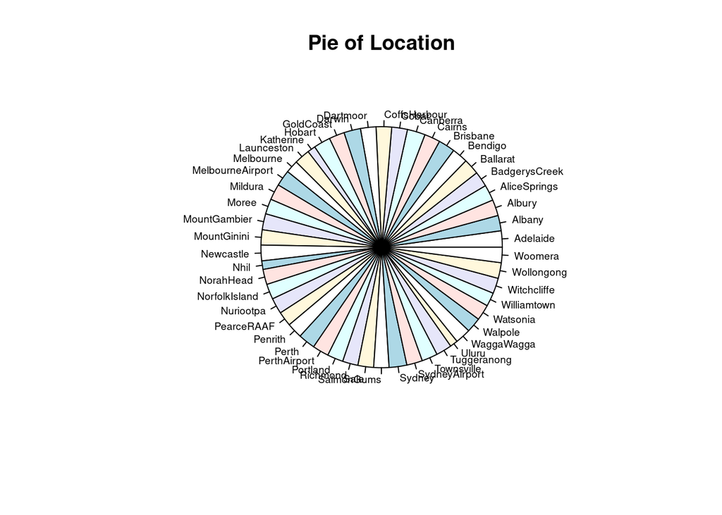

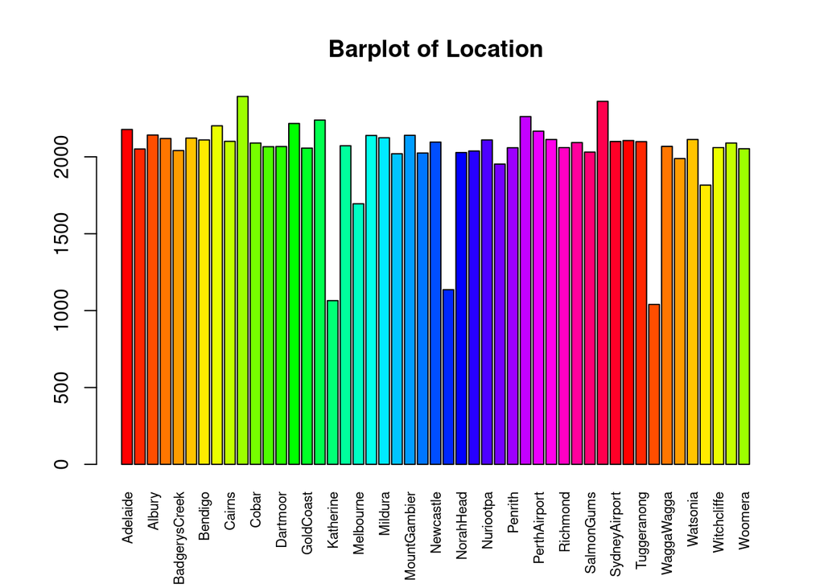

```
## [1] "Number of modalities:  49"
## [1] "Frequency table"
##
##         Adelaide           Albany           Albury     AliceSprings
##             2178             2051             2142             2119
##    BadgerysCreek         Ballarat          Bendigo         Brisbane
##             2041             2122             2110             2202
##           Cairns         Canberra            Cobar     CoffsHarbour
##             2101             2393             2090             2066
##         Dartmoor           Darwin        GoldCoast           Hobart
##             2067             2217             2057             2239
##        Katherine       Launceston        Melbourne MelbourneAirport
##             1065             2072             1695             2139
##          Mildura            Moree     MountGambier      MountGinini
##             2124             2020             2140             2025
##        Newcastle             Nhil        NorahHead    NorfolkIsland
##             2096             1136             2028             2038
##        Nuriootpa       PearceRAAF          Penrith            Perth
##             2110             1953             2059             2262
##     PerthAirport         Portland         Richmond             Sale
##             2167             2113             2060             2093
##       SalmonGums           Sydney    SydneyAirport       Townsville
##             2031             2361             2100             2106
##      Tuggeranong            Uluru       WaggaWagga          Walpole
##             2099             1040             2068             1989
##         Watsonia      Williamtown      Witchcliffe       Wollongong
##             2113             1816             2060             2090
##          Woomera
##             2053
## [1] "Relative frequency table (proportions)"
##
##         Adelaide           Albany           Albury     AliceSprings
##       0.02188593       0.02060975       0.02152418       0.02129306
##    BadgerysCreek         Ballarat          Bendigo         Brisbane
##       0.02050926       0.02132320       0.02120262       0.02212710
##           Cairns         Canberra            Cobar     CoffsHarbour
##       0.02111218       0.02404638       0.02100165       0.02076048
##         Dartmoor           Darwin        GoldCoast           Hobart
##       0.02077053       0.02227782       0.02067004       0.02249889
##        Katherine       Launceston        Melbourne MelbourneAirport
```

[output cut: 59 more lines]

```
##            Cobar       Wollongong       Launceston       WaggaWagga
##       0.02100165       0.02100165       0.02082077       0.02078058
##         Dartmoor     CoffsHarbour         Richmond      Witchcliffe
##       0.02077053       0.02076048       0.02070019       0.02070019
##          Penrith        GoldCoast          Woomera           Albany
##       0.02069014       0.02067004       0.02062985       0.02060975
##    BadgerysCreek    NorfolkIsland       SalmonGums        NorahHead
##       0.02050926       0.02047912       0.02040878       0.02037863
##      MountGinini            Moree          Walpole       PearceRAAF
##       0.02034849       0.02029824       0.01998674       0.01962498
##      Williamtown        Melbourne             Nhil        Katherine
##       0.01824832       0.01703244       0.01141525       0.01070180
##            Uluru
##       0.01045058
## [1] "variable  3 : MinTemp"
```

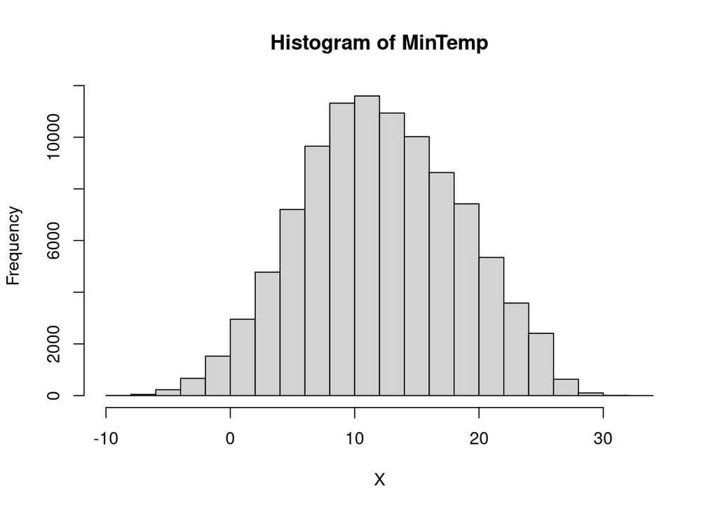

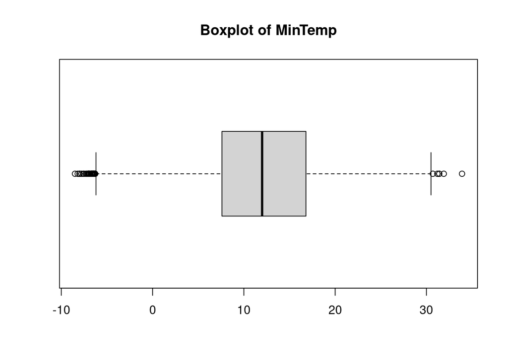

```
## [1] "Extended Summary Statistics"
##    Min. 1st Qu.  Median    Mean 3rd Qu.    Max.    NA's
##   -8.50    7.60   12.00   12.18   16.80   33.90     443
## [1] "sd:  6.39088229056526"
## [1] "vc:  0.524863886685579"
## [1] "variable  4 : MaxTemp"
```

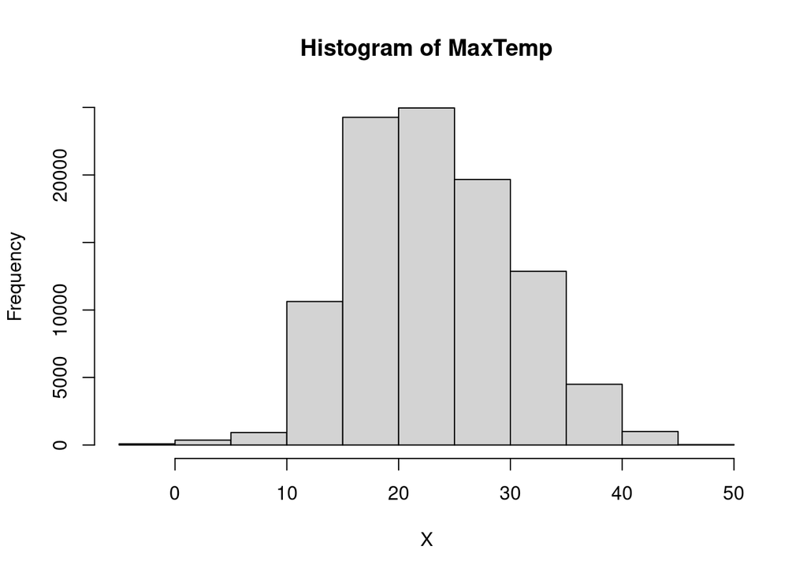

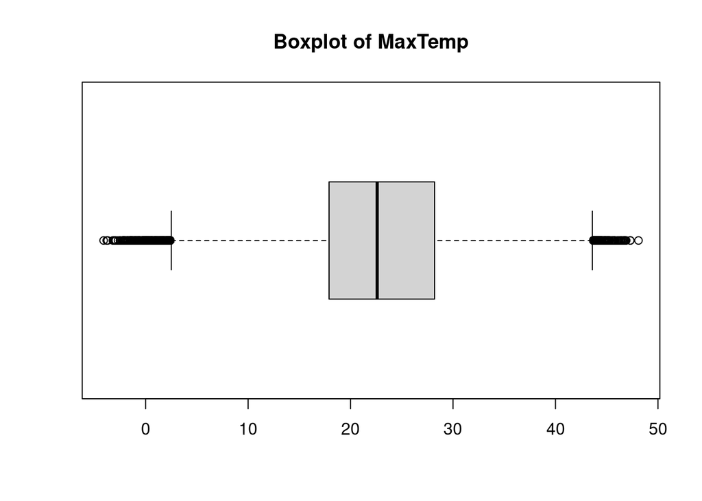

```
## [1] "Extended Summary Statistics"
##    Min. 1st Qu.  Median    Mean 3rd Qu.    Max.    NA's
##   -4.10   17.90   22.60   23.22   28.20   48.10     230
## [1] "sd:  7.11507239837278"
## [1] "vc:  0.306439621777097"
## [1] "variable  5 : Rainfall"
```

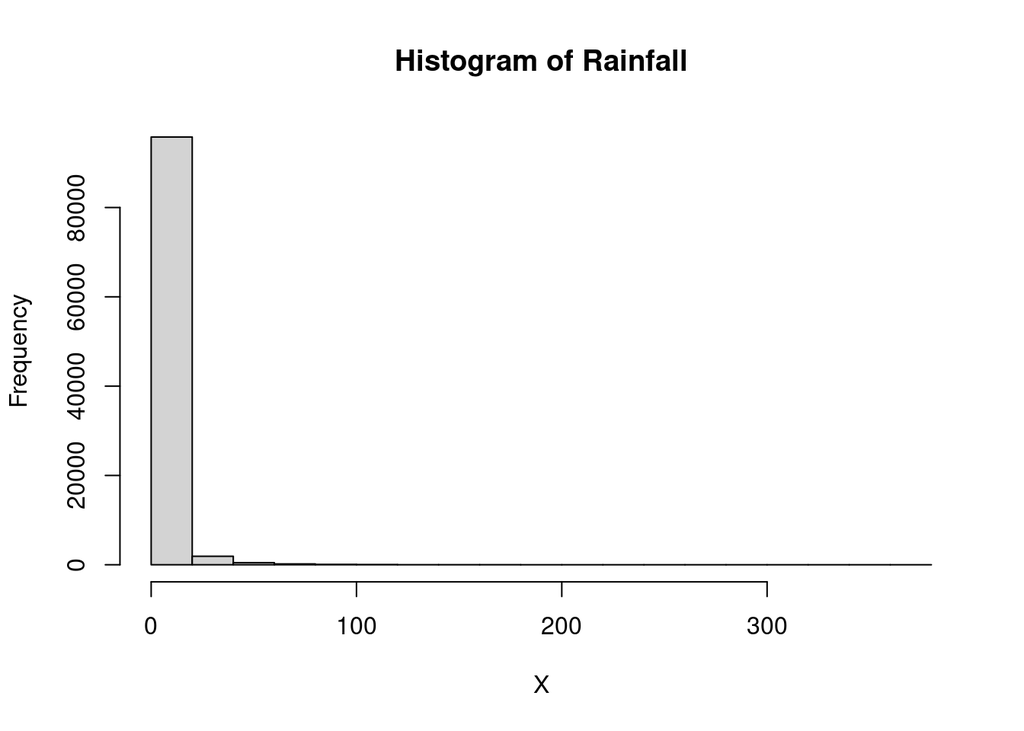

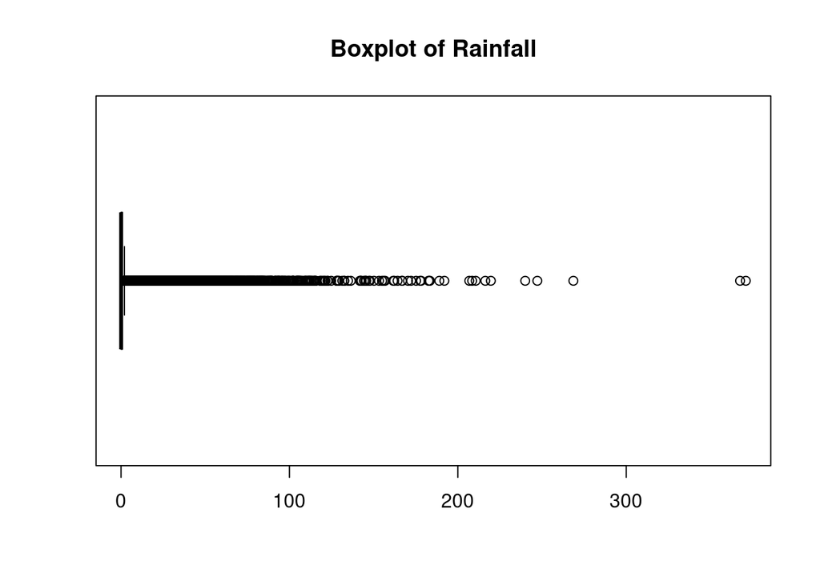

```
## [1] "Extended Summary Statistics"
##    Min. 1st Qu.  Median    Mean 3rd Qu.    Max.    NA's
##   0.000   0.000   0.000   2.353   0.800 371.000     979
## [1] "sd:  8.4878657266372"
## [1] "vc:  3.60721636257779"
## [1] "variable  6 : Evaporation"
```

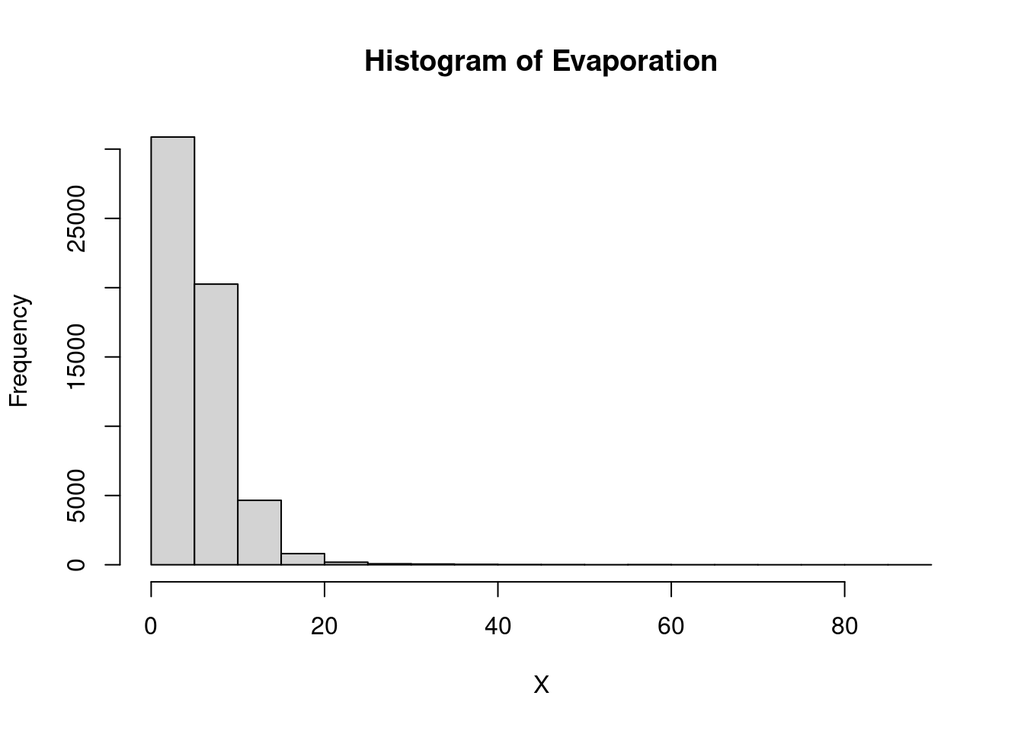

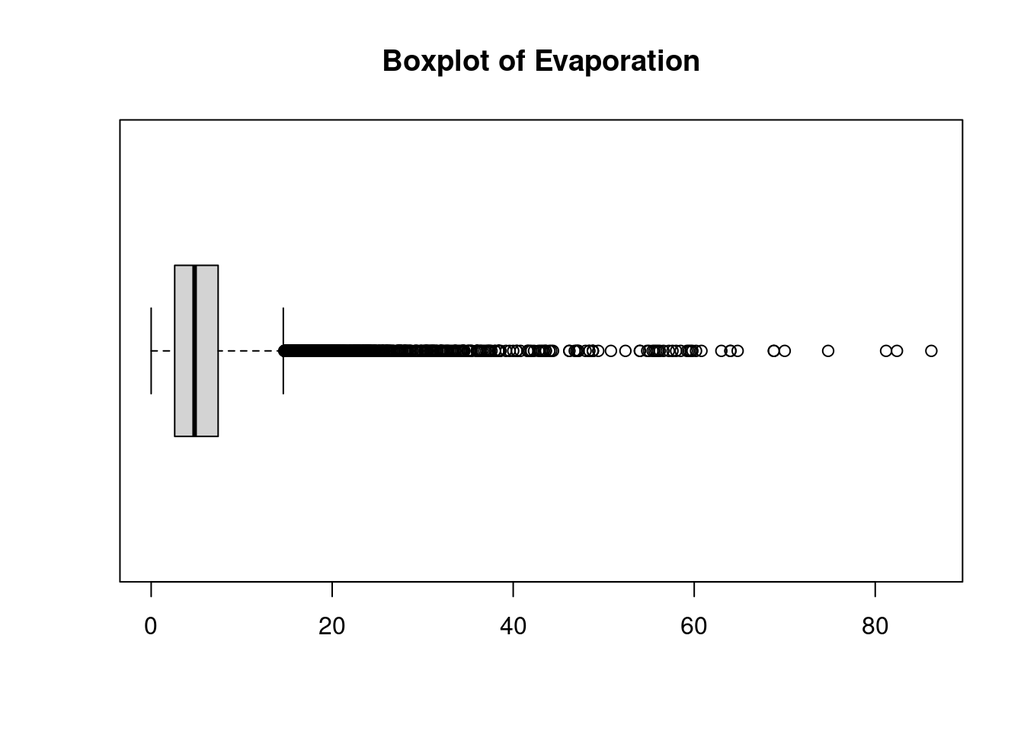

```
## [1] "Extended Summary Statistics"
##    Min. 1st Qu.  Median    Mean 3rd Qu.    Max.    NA's
##    0.00    2.60    4.80    5.46    7.40   86.20   42531
## [1] "sd:  4.16249044462289"
## [1] "vc:  0.762176674283636"
## [1] "variable  7 : Sunshine"
```

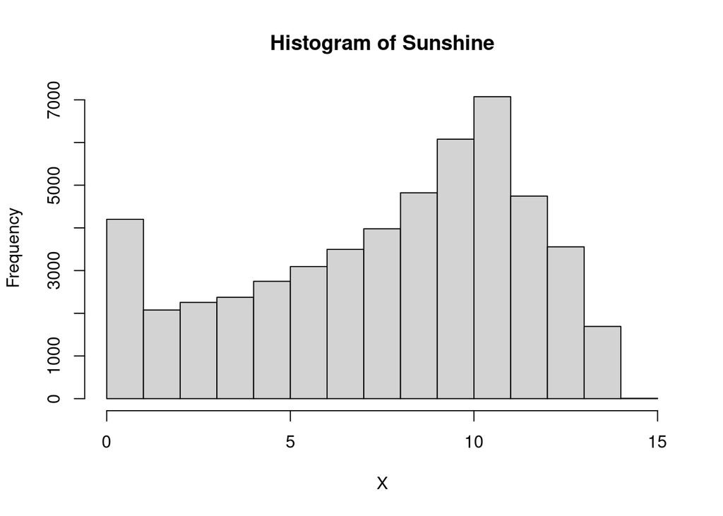

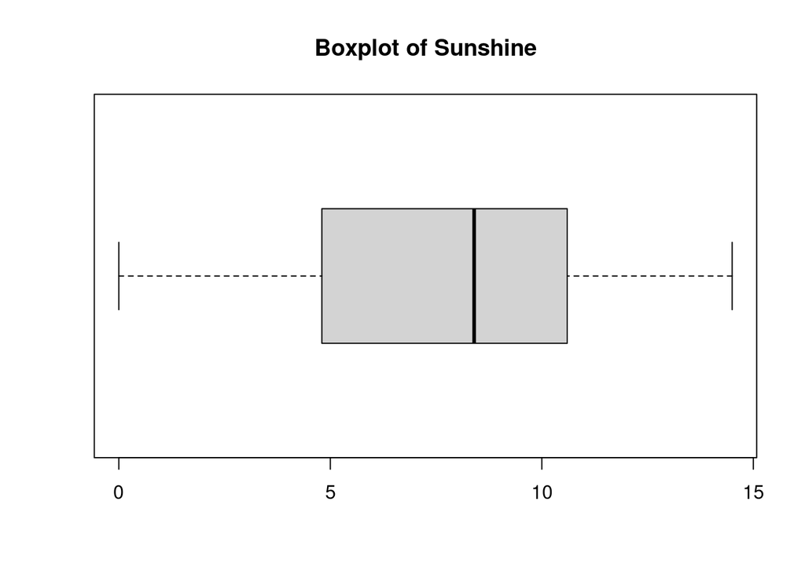

```
## [1] "Extended Summary Statistics"
##    Min. 1st Qu.  Median    Mean 3rd Qu.    Max.    NA's
##    0.00    4.80    8.40    7.62   10.60   14.50   47317
## [1] "sd:  3.78300764622474"
## [1] "vc:  0.496777777226433"
## [1] "variable  8 : WindGustDir"
```

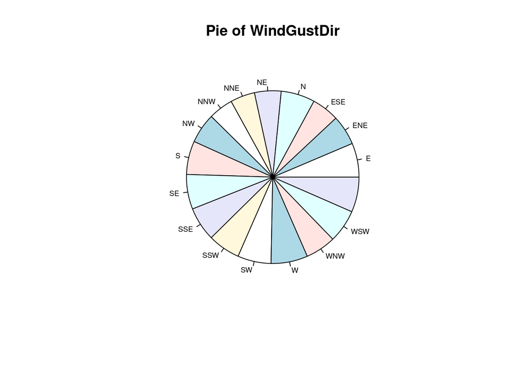

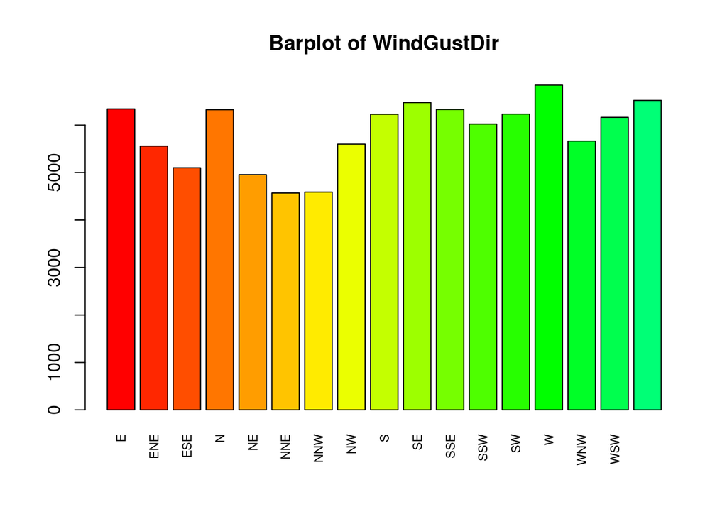

```
## [1] "Number of modalities:  17"
## [1] "Frequency table"
##
##    E  ENE  ESE    N   NE  NNE  NNW   NW    S   SE  SSE  SSW   SW    W  WNW  WSW
## 6341 5558 5101 6323 4956 4569 4589 5599 6228 6475 6329 6023 6233 6843 5664 6164
## <NA>
## 6521
## [1] "Relative frequency table (proportions)"
##
##          E        ENE        ESE          N         NE        NNE        NNW
## 0.06371840 0.05585032 0.05125809 0.06353752 0.04980104 0.04591222 0.04611319
##         NW          S         SE        SSE        SSW         SW          W
## 0.05626231 0.06258290 0.06506491 0.06359781 0.06052293 0.06263314 0.06876281
##        WNW        WSW       <NA>
## 0.05691547 0.06193979 0.06552715
## [1] "Frequency table sorted"
##
##    W <NA>   SE    E  SSE    N   SW    S  WSW  SSW  WNW   NW  ENE  ESE   NE  NNW
## 6843 6521 6475 6341 6329 6323 6233 6228 6164 6023 5664 5599 5558 5101 4956 4589
##  NNE
## 4569
## [1] "Relative frequency table (proportions) sorted"
##
##          W       <NA>         SE          E        SSE          N         SW
## 0.06876281 0.06552715 0.06506491 0.06371840 0.06359781 0.06353752 0.06263314
##          S        WSW        SSW        WNW         NW        ENE        ESE
## 0.06258290 0.06193979 0.06052293 0.05691547 0.05626231 0.05585032 0.05125809
##         NE        NNW        NNE
## 0.04980104 0.04611319 0.04591222
## [1] "variable  9 : WindGustSpeed"
```

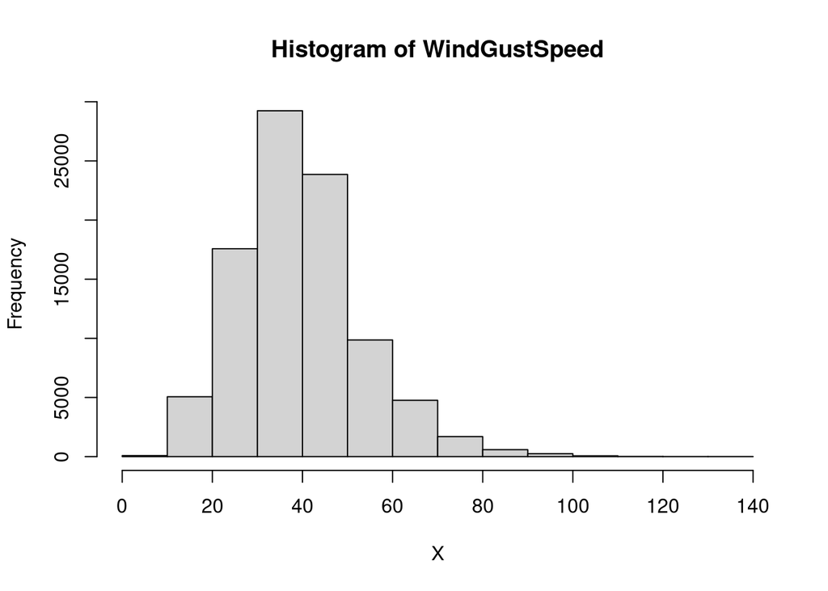

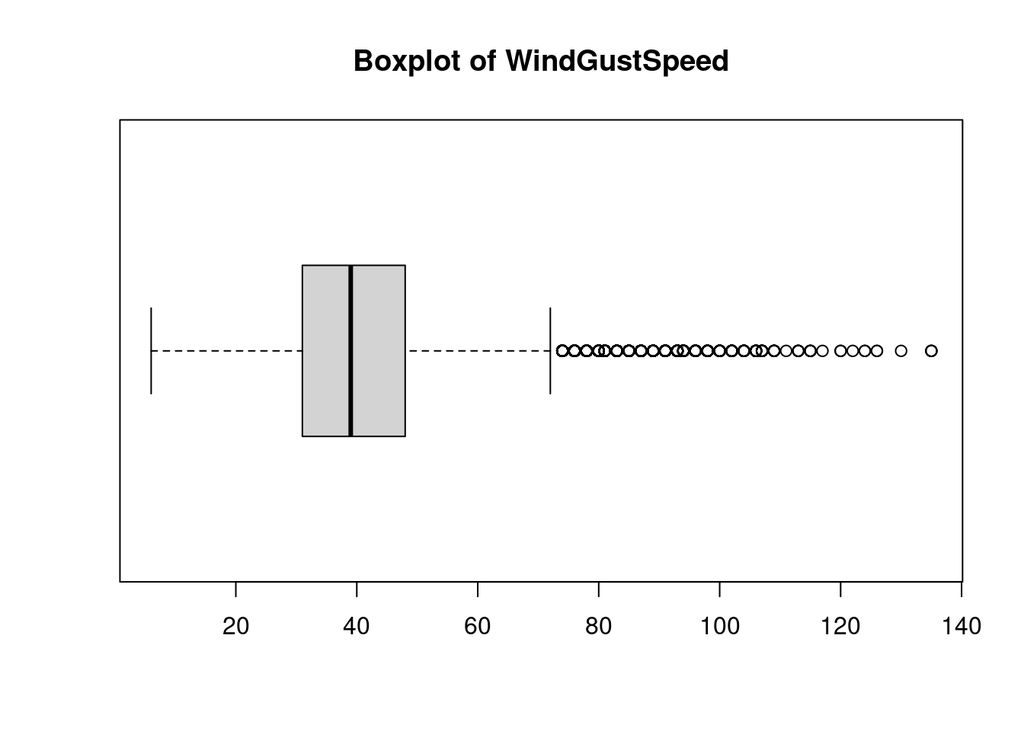

```
## [1] "Extended Summary Statistics"
##    Min. 1st Qu.  Median    Mean 3rd Qu.    Max.    NA's
##    6.00   31.00   39.00   39.98   48.00  135.00    6480
## [1] "sd:  13.5815235085385"
## [1] "vc:  0.3397337241797"
## [1] "variable  10 : WindDir9am"
```

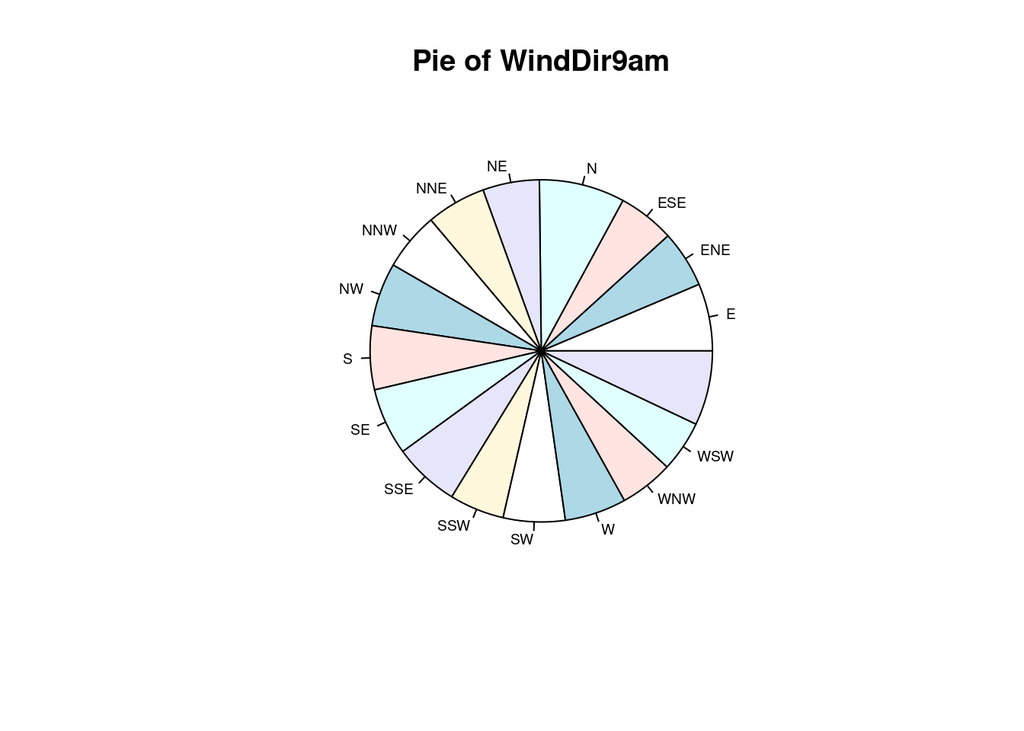

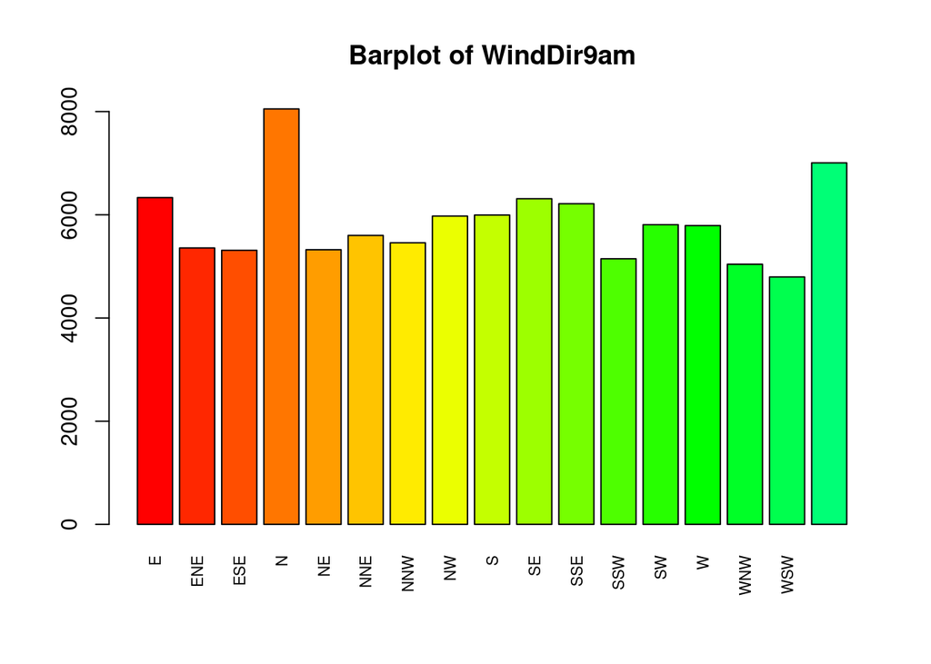

```
## [1] "Number of modalities:  17"
## [1] "Frequency table"
##
##    E  ENE  ESE    N   NE  NNE  NNW   NW    S   SE  SSE  SSW   SW    W  WNW  WSW
## 6333 5357 5312 8052 5323 5600 5457 5975 5995 6311 6214 5147 5808 5790 5041 4795
## <NA>
## 7006
## [1] "Relative frequency table (proportions)"
##
##          E        ENE        ESE          N         NE        NNE        NNW
## 0.06363801 0.05383054 0.05337835 0.08091161 0.05348889 0.05627236 0.05483540
##         NW          S         SE        SSE        SSW         SW          W
## 0.06004060 0.06024157 0.06341694 0.06244222 0.05172033 0.05836247 0.05818160
##        WNW        WSW       <NA>
## 0.05065517 0.04818321 0.07040074
## [1] "Frequency table sorted"
##
##    N <NA>    E   SE  SSE    S   NW   SW    W  NNE  NNW  ENE   NE  ESE  SSW  WNW
## 8052 7006 6333 6311 6214 5995 5975 5808 5790 5600 5457 5357 5323 5312 5147 5041
##  WSW
## 4795
## [1] "Relative frequency table (proportions) sorted"
##
##          N       <NA>          E         SE        SSE          S         NW
## 0.08091161 0.07040074 0.06363801 0.06341694 0.06244222 0.06024157 0.06004060
##         SW          W        NNE        NNW        ENE         NE        ESE
## 0.05836247 0.05818160 0.05627236 0.05483540 0.05383054 0.05348889 0.05337835
##        SSW        WNW        WSW
## 0.05172033 0.05065517 0.04818321
## [1] "variable  11 : WindDir3pm"
```

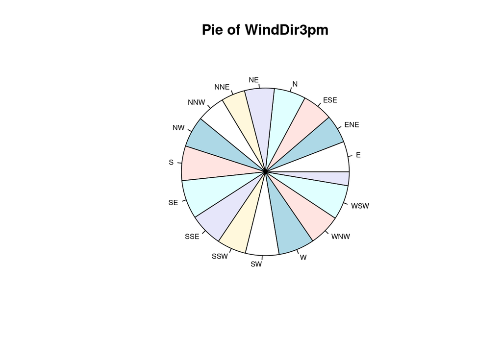

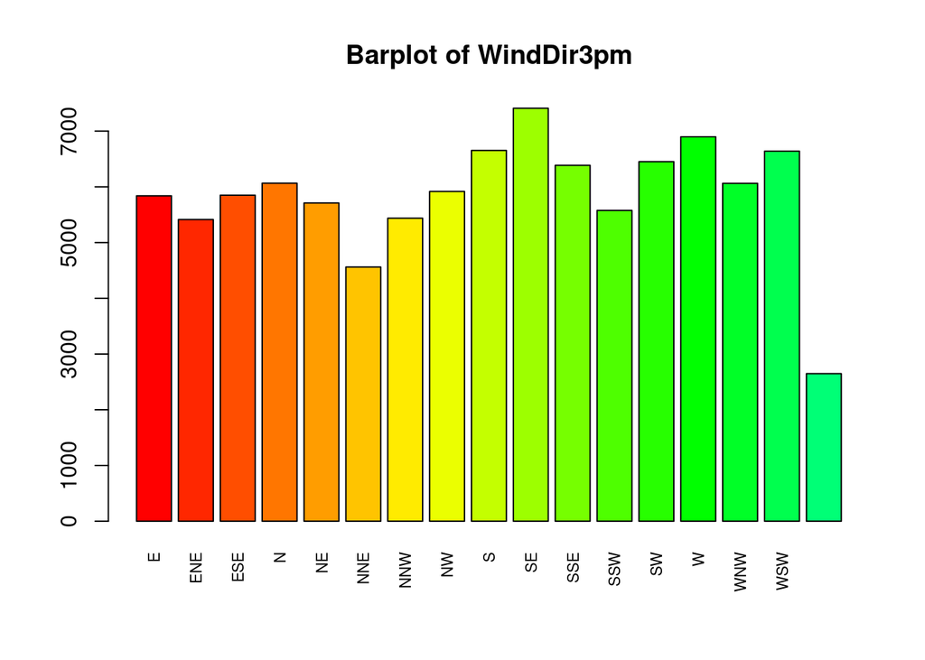

```
## [1] "Number of modalities:  17"
## [1] "Frequency table"
##
##    E  ENE  ESE    N   NE  NNE  NNW   NW    S   SE  SSE  SSW   SW    W  WNW  WSW
## 5839 5413 5850 6065 5710 4561 5437 5917 6653 7410 6386 5576 6451 6897 6063 6640
## <NA>
## 2648
## [1] "Relative frequency table (proportions)"
##
##          E        ENE        ESE          N         NE        NNE        NNW
## 0.05867398 0.05439326 0.05878452 0.06094497 0.05737771 0.04583183 0.05463443
##         NW          S         SE        SSE        SSW         SW          W
## 0.05945778 0.06685357 0.07446039 0.06417059 0.05603119 0.06482375 0.06930544
##        WNW        WSW       <NA>
## 0.06092488 0.06672294 0.02660879
## [1] "Frequency table sorted"
##
##   SE    W    S  WSW   SW  SSE    N  WNW   NW  ESE    E   NE  SSW  NNW  ENE  NNE
## 7410 6897 6653 6640 6451 6386 6065 6063 5917 5850 5839 5710 5576 5437 5413 4561
## <NA>
## 2648
## [1] "Relative frequency table (proportions) sorted"
##
##         SE          W          S        WSW         SW        SSE          N
## 0.07446039 0.06930544 0.06685357 0.06672294 0.06482375 0.06417059 0.06094497
##        WNW         NW        ESE          E         NE        SSW        NNW
## 0.06092488 0.05945778 0.05878452 0.05867398 0.05737771 0.05603119 0.05463443
##        ENE        NNE       <NA>
## 0.05439326 0.04583183 0.02660879
## [1] "variable  12 : WindSpeed9am"
```

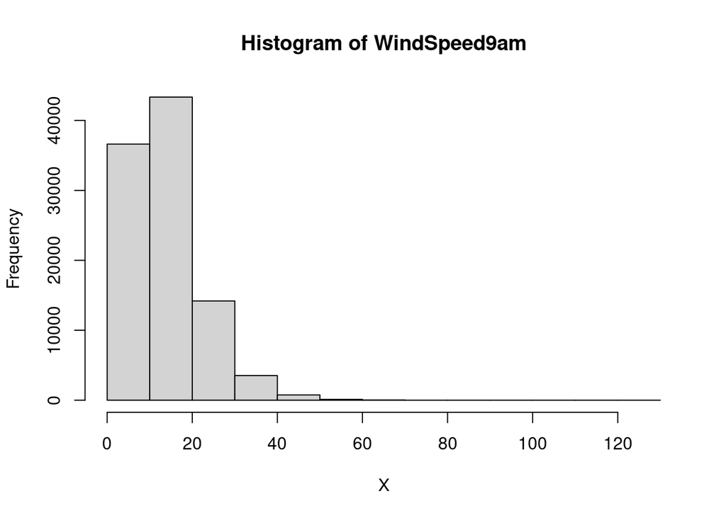

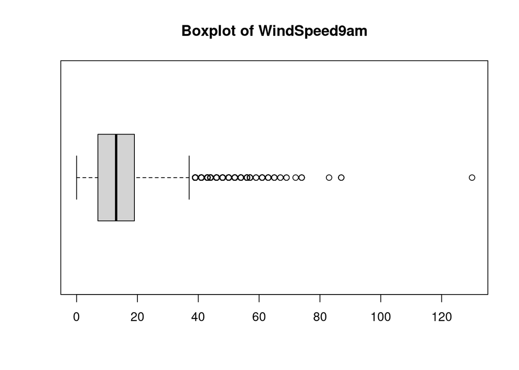

```
## [1] "Extended Summary Statistics"
##    Min. 1st Qu.  Median    Mean 3rd Qu.    Max.    NA's
##       0       7      13      14      19     130     935
## [1] "sd:  8.90232250230192"
## [1] "vc:  0.635660022221613"
## [1] "variable  13 : WindSpeed3pm"
```

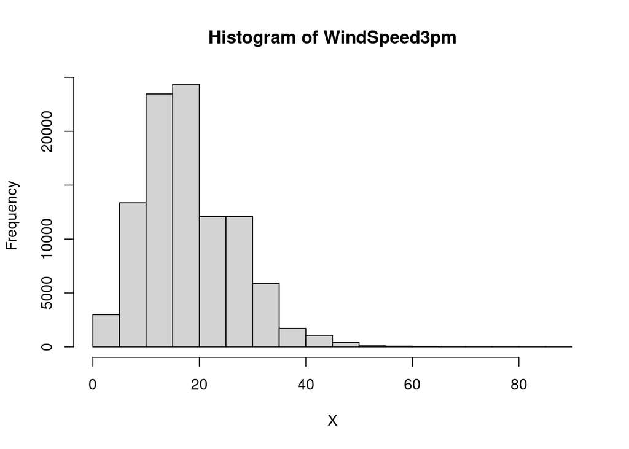

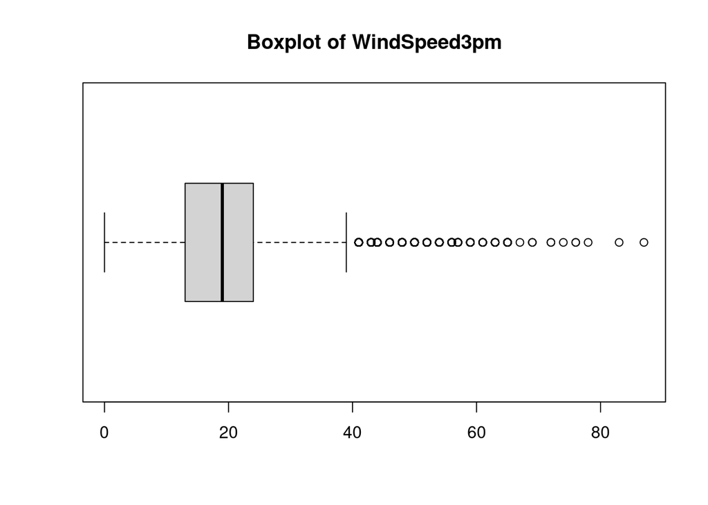

```
## [1] "Extended Summary Statistics"
##    Min. 1st Qu.  Median    Mean 3rd Qu.    Max.    NA's
##    0.00   13.00   19.00   18.65   24.00   87.00    1835
## [1] "sd:  8.80182720672024"
## [1] "vc:  0.471936091296523"
## [1] "variable  14 : Humidity9am"
```

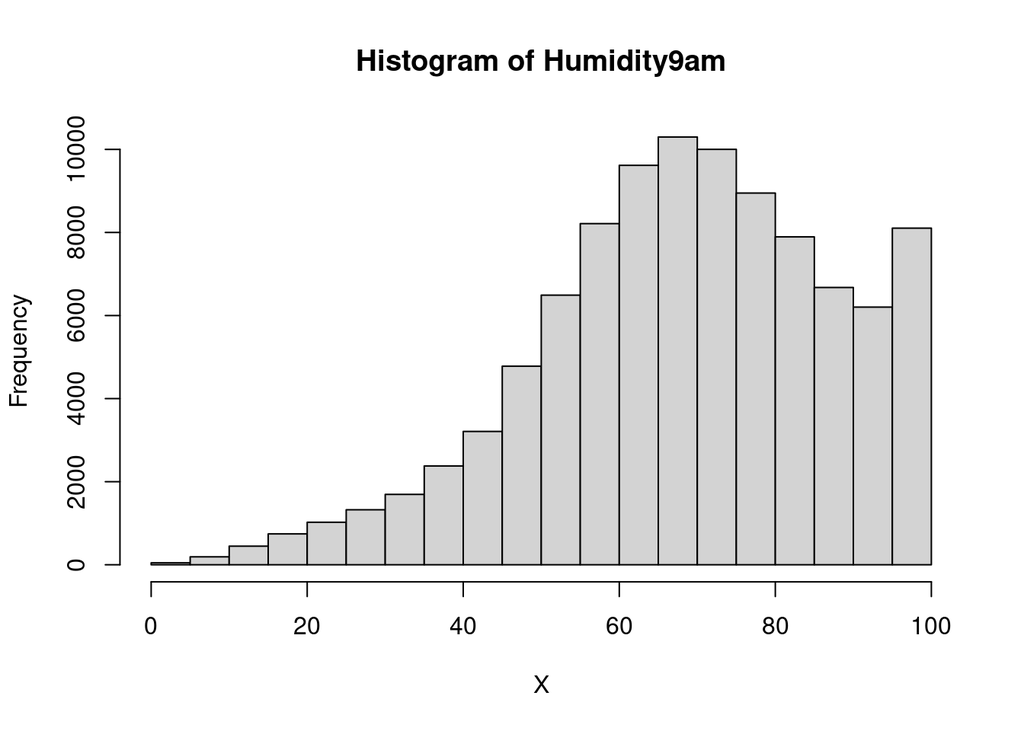

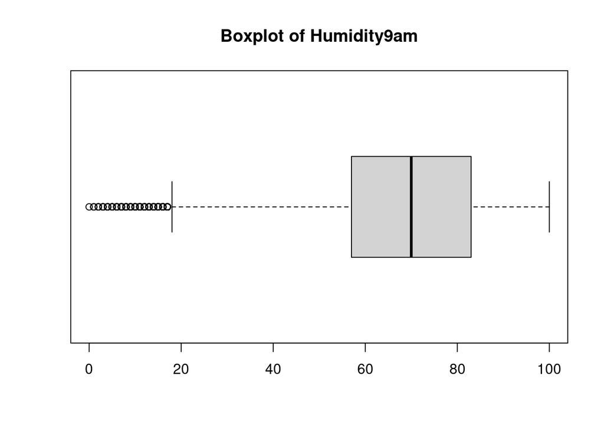

```
## [1] "Extended Summary Statistics"
##    Min. 1st Qu.  Median    Mean 3rd Qu.    Max.    NA's
##    0.00   57.00   70.00   68.87   83.00  100.00    1233
## [1] "sd:  19.0749513463571"
## [1] "vc:  0.276984975043417"
## [1] "variable  15 : Humidity3pm"
```

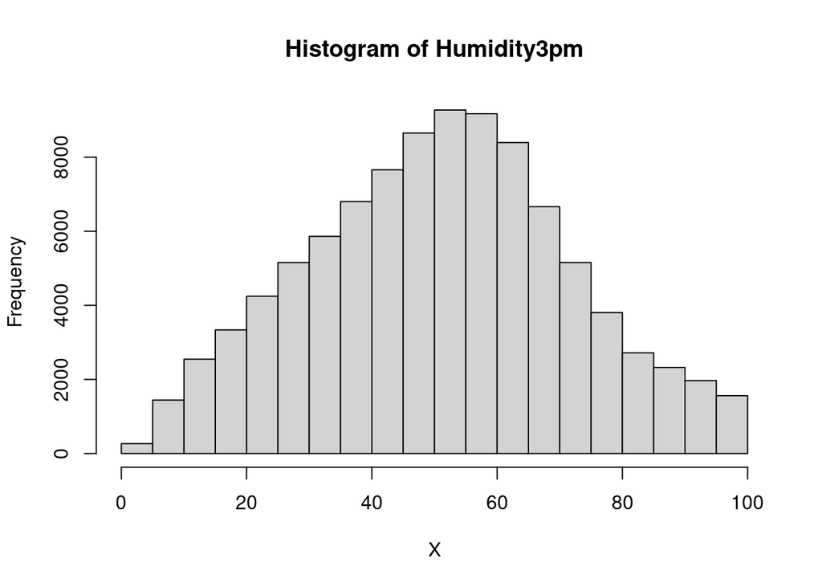

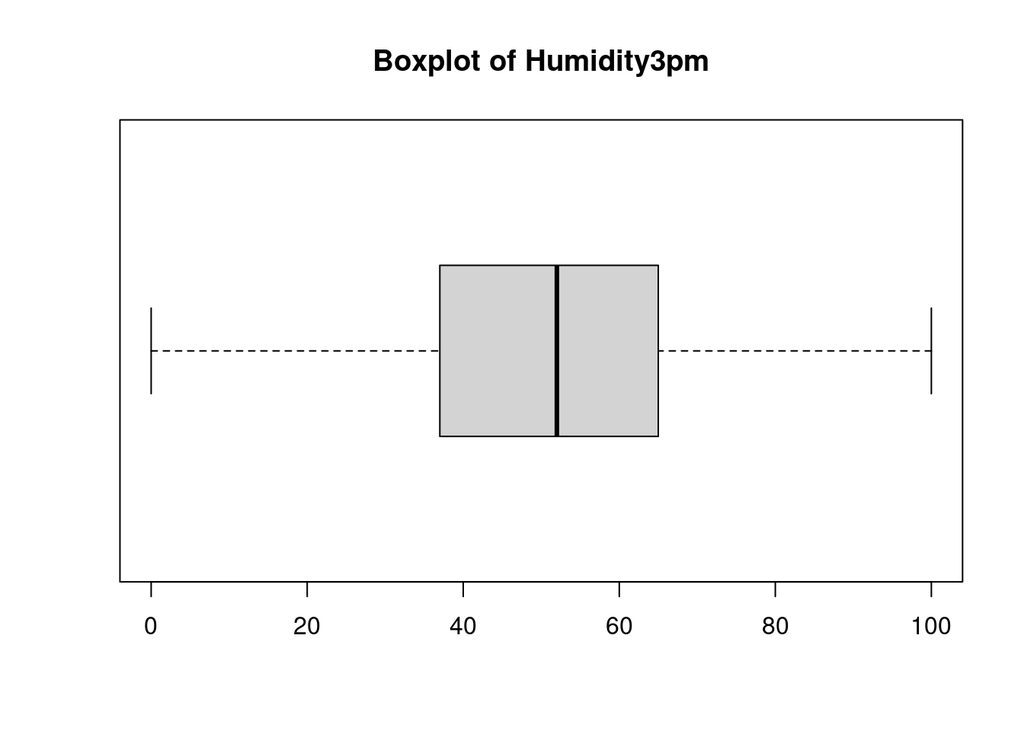

```
## [1] "Extended Summary Statistics"
##    Min. 1st Qu.  Median    Mean 3rd Qu.    Max.    NA's
##    0.00   37.00   52.00   51.43   65.00  100.00    2506
## [1] "sd:  20.7776161952411"
## [1] "vc:  0.403972095866944"
## [1] "variable  16 : Pressure9am"
```

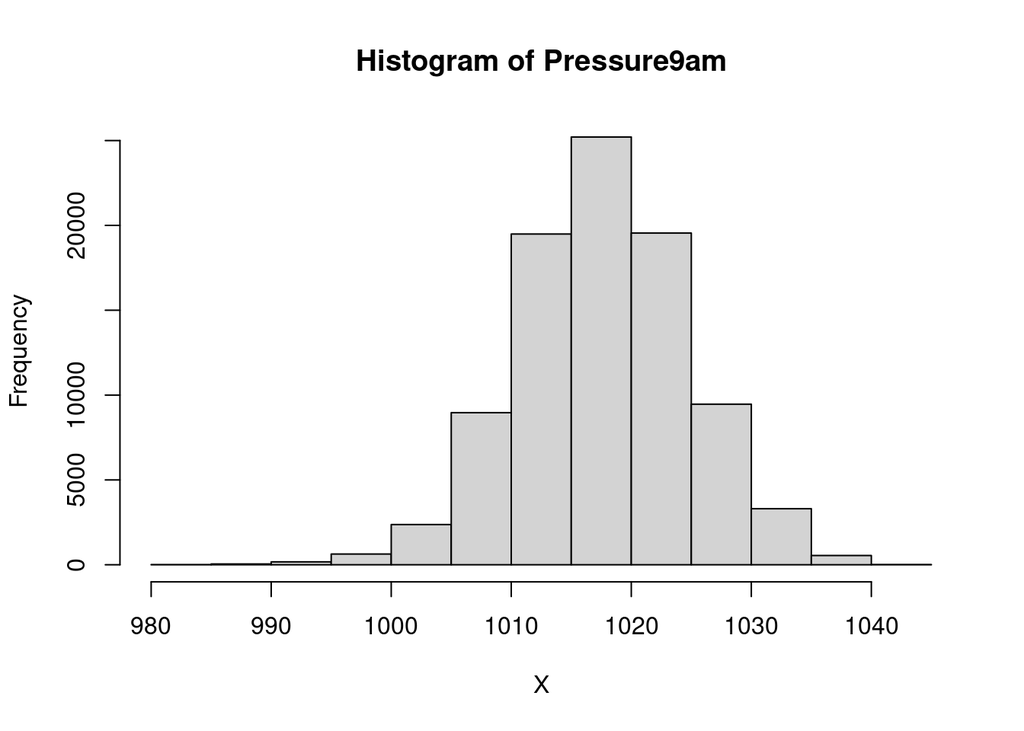

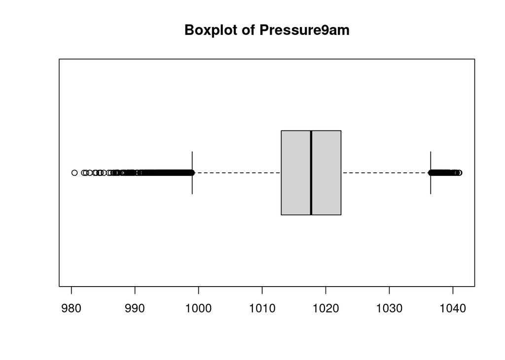

```
## [1] "Extended Summary Statistics"
##    Min. 1st Qu.  Median    Mean 3rd Qu.    Max.    NA's
##   980.5  1013.0  1017.7  1017.7  1022.4  1041.0    9748
## [1] "sd:  7.11016624760789"
## [1] "vc:  0.00698661056762593"
## [1] "variable  17 : Pressure3pm"
```

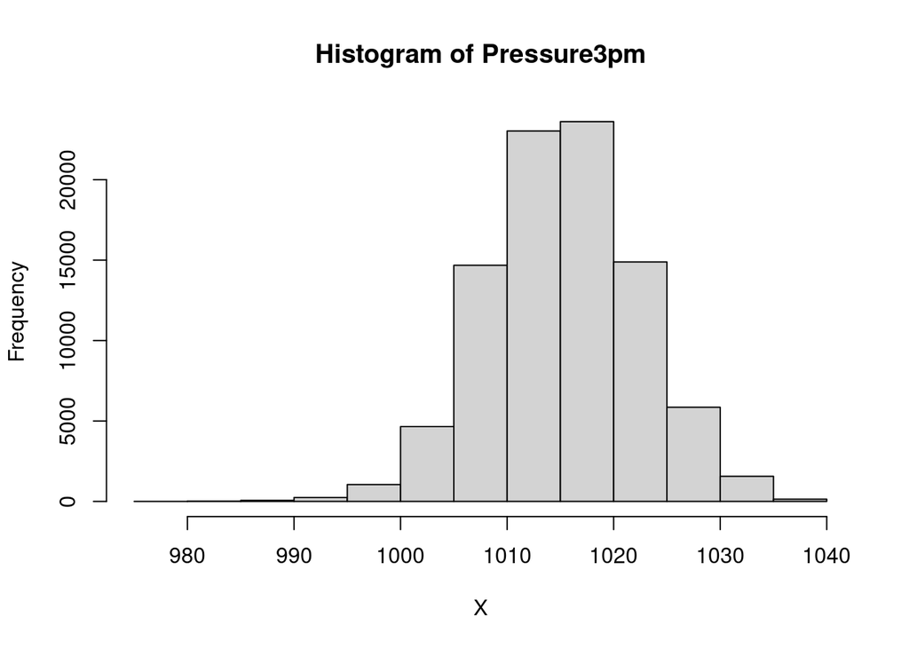

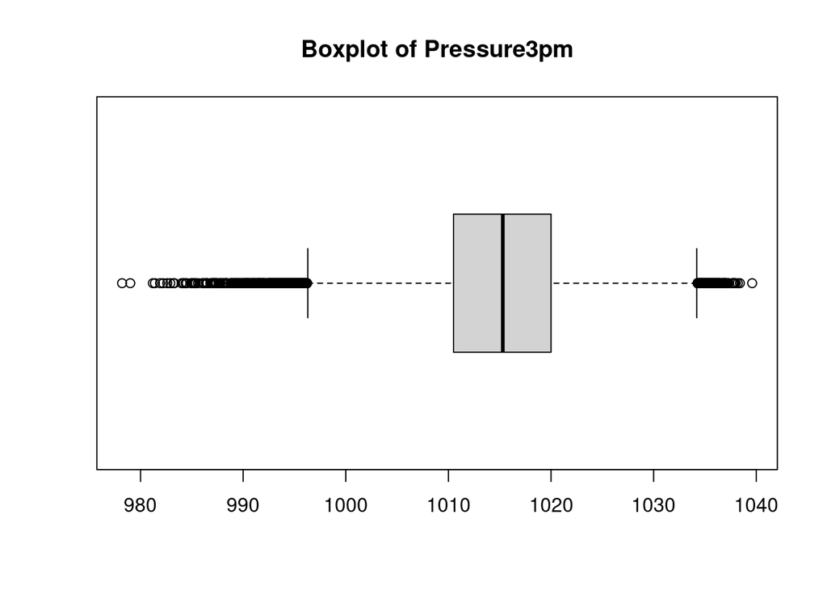

```
## [1] "Extended Summary Statistics"
##    Min. 1st Qu.  Median    Mean 3rd Qu.    Max.    NA's
##   978.2  1010.5  1015.3  1015.3  1020.0  1039.6    9736
## [1] "sd:  7.04518877022009"
## [1] "vc:  0.00693911602553753"
## [1] "variable  18 : Cloud9am"
```